# Cyclistic Bike-share Analysis

Khang Nguyen Duy

3/22/2022

# Quiz Intro

- Welcome to the Cyclistic Bike-share Analysis case study! This case study is to verify my learning steps of studying in the Data Analyst course - Google
- We will be using the [Divvy Dataset](http://divvy-tripdata.s3.amazonaws.com/index.html) for this case study. The data has been made publicly available by Motivate International Inc, under this [license](http://www.divvybikes.com/data-license-agreement).

# Scenario

I am a junior data analyst working in the marketing analyst team at Cyclistic, a bike-share company in Chicago. The director of marketing believes the company’s future success depends on maximizing the number of annual memberships. Therefore, my team wants to understand how casual riders and annual members use Cyclistic bikes differently. From these insights, my team will design a new marketing strategy to convert casual riders into annual members.

# Mission statement

Cyclistic company wants to analyze their user data to find the main differences in behaviour between their two types of users, the “casual” who pays for each ride and the annual member who pays a yearly subscription to the service.

# I. Ask

## 1. Identify the business task:

The company wants to improve their earnings reaching out to their “casual” riders, and for that they have to analyze in what aspects the casual and the annual customers differ, to be able to create a focused and successful marketing message to the “casual” customers that makes them change to the annual subscription.

## 2. Consider key stakeholders:

The main stakeholders here are the director of marketing and my manager Lily Moreno, the rest of the marketing analytics team, and the Cyclistic executive team.

# II. Prepare

## 1. Determine the credibility of the data:

The data is public data from a bike sharing company. It starts from the year 2013 until 2021 (three months), there isn’t much of a naming convention as the files are sometimes organized by quarter, or month, or the whole year and their names vary a lot. The naming of the columns also changes and there are some columns added and deleted over the years. Nevertheless the data seems to be in good condition and its first hand data collected by the company itself with lots of entries and with lots of useful data.

## 2. Sort and filter the data:

For this analysis I’m going to focus on the 2020-2021 period as it’s the more relevant period to the business task and it has the more complete data with geo-location coordinates, and types of bike used.

- First I add all the libraries necessary to my analysis.

```r
library("tidyverse")
```

```r
library("ggplot2")
library("lubridate")
library("geosphere")
library("gridExtra")
library("ggmap")
library("readr")
```

- Second, I load all the data to their respective variables.

```r
apr_2020 <- read.csv("~/Documents/DATA ANALYTICS/Cyclistic - Case Study/Datasets/202004-divvy-tripdata.csv")
may_2020 <- read.csv("~/Documents/DATA ANALYTICS/Cyclistic - Case Study/Datasets/202005-divvy-tripdata.csv")
jun_2020 <- read.csv("~/Documents/DATA ANALYTICS/Cyclistic - Case Study/Datasets/202006-divvy-tripdata.csv")
jul_2020 <- read.csv("~/Documents/DATA ANALYTICS/Cyclistic - Case Study/Datasets/202007-divvy-tripdata.csv")
agu_2020 <- read.csv("~/Documents/DATA ANALYTICS/Cyclistic - Case Study/Datasets/202008-divvy-tripdata.csv")
sep_2020 <- read.csv("~/Documents/DATA ANALYTICS/Cyclistic - Case Study/Datasets/202009-divvy-tripdata.csv")
oct_2020 <- read.csv("~/Documents/DATA ANALYTICS/Cyclistic - Case Study/Datasets/202010-divvy-tripdata.csv")
nov_2020 <- read.csv("~/Documents/DATA ANALYTICS/Cyclistic - Case Study/Datasets/202011-divvy-tripdata.csv")
dec_2020 <- read.csv("~/Documents/DATA ANALYTICS/Cyclistic - Case Study/Datasets/202012-divvy-tripdata.csv")
jan_2021 <- read.csv("~/Documents/DATA ANALYTICS/Cyclistic - Case Study/Datasets/202101-divvy-tripdata.csv")
feb_2021 <- read.csv("~/Documents/DATA ANALYTICS/Cyclistic - Case Study/Datasets/202102-divvy-tripdata.csv")
mar_2021 <- read.csv("~/Documents/DATA ANALYTICS/Cyclistic - Case Study/Datasets/202103-divvy-tripdata.csv")
```

```r
withDoubles_tripdata <- bind_rows(apr_2020, may_2020, jun_2020,jul_2020, agu_2020, sep_2020, oct_2020, nov_2020)
withDoubles_tripdata <- mutate(withDoubles_tripdata, start_station_id = as.character(start_station_id), end_station_id = as.character(end_station_id))
withChar_tripdata <- bind_rows(dec_2020, jan_2021, feb_2021, mar_2021)
# Join all the data
all_tripdata <- bind_rows(withDoubles_tripdata, withChar_tripdata)
```

# III. Process

## 1. Clean the data, and prepare the data for analysis:

Now that we have all the data in one place we can start to clean the data of possible errors like NA. Also we will make some changes to the data adding useful new columns based on calculations of already existing columns in order to facilitate our analysis and arrive at more insightful conclusions.

```r
# overview of data
print("============== GLIMPSE ==============")
```

```
## [1] "============== GLIMPSE =============="
```

```r
glimpse(all_tripdata)
```

```
## Rows: 3,489,748
## Columns: 13
## $ ride_id            <chr> "A847FADBBC638E45", "5405B80E996FF60D", "5DD24A79A4…
## $ rideable_type      <chr> "docked_bike", "docked_bike", "docked_bike", "docke…
## $ started_at         <chr> "2020-04-26 17:45:14", "2020-04-17 17:08:54", "2020…
## $ ended_at           <chr> "2020-04-26 18:12:03", "2020-04-17 17:17:03", "2020…
## $ start_station_name <chr> "Eckhart Park", "Drake Ave & Fullerton Ave", "McClu…
## $ start_station_id   <chr> "86", "503", "142", "216", "125", "173", "35", "434…
## $ end_station_name   <chr> "Lincoln Ave & Diversey Pkwy", "Kosciuszko Park", "…
## $ end_station_id     <chr> "152", "499", "255", "657", "323", "35", "635", "38…
## $ start_lat          <dbl> 41.8964, 41.9244, 41.8945, 41.9030, 41.8902, 41.896…
## $ start_lng          <dbl> -87.6610, -87.7154, -87.6179, -87.6975, -87.6262, -…
## $ end_lat            <dbl> 41.9322, 41.9306, 41.8679, 41.8992, 41.9695, 41.892…
## $ end_lng            <dbl> -87.6586, -87.7238, -87.6230, -87.6722, -87.6547, -…
## $ member_casual      <chr> "member", "member", "member", "member", "casual", "…
```

```r
print("============== SUMMARY ==============")
```

```
## [1] "============== SUMMARY =============="
```

```r
summary(all_tripdata)
```

```
##    ride_id          rideable_type       started_at          ended_at
##  Length:3489748     Length:3489748     Length:3489748     Length:3489748
##  Class :character   Class :character   Class :character   Class :character
##  Mode  :character   Mode  :character   Mode  :character   Mode  :character
##
##
##
##
##  start_station_name start_station_id   end_station_name   end_station_id
##  Length:3489748     Length:3489748     Length:3489748     Length:3489748
##  Class :character   Class :character   Class :character   Class :character
##  Mode  :character   Mode  :character   Mode  :character   Mode  :character
##
##
##
##
##    start_lat       start_lng         end_lat         end_lng
##  Min.   :41.64   Min.   :-87.87   Min.   :41.54   Min.   :-88.07
##  1st Qu.:41.88   1st Qu.:-87.66   1st Qu.:41.88   1st Qu.:-87.66
##  Median :41.90   Median :-87.64   Median :41.90   Median :-87.64
##  Mean   :41.90   Mean   :-87.64   Mean   :41.90   Mean   :-87.64
##  3rd Qu.:41.93   3rd Qu.:-87.63   3rd Qu.:41.93   3rd Qu.:-87.63
##  Max.   :42.08   Max.   :-87.52   Max.   :42.16   Max.   :-87.44
##                                   NA's   :4738    NA's   :4738
##  member_casual
##  Length:3489748
##  Class :character
##  Mode  :character
##
##
##
##
```

Now lets clean the data to be able to properly work with it.

- Let’s drop all NA value.

```r
all_tripdata_clean <- drop_na(all_tripdata)
```

## 2. Create some new columns:

- First, let’s separate the dates into month, day, year and day of the week:

```r
all_tripdata_clean$date <- as.Date(all_tripdata_clean$started_at)
all_tripdata_clean$month <- format(as.Date(all_tripdata_clean$date), "%m")
all_tripdata_clean$day <- format(as.Date(all_tripdata_clean$date), "%d")
all_tripdata_clean$year <- format(as.Date(all_tripdata_clean$date), "%Y")
all_tripdata_clean$day_of_week <- format(as.Date(all_tripdata_clean$date), "%A")
```

- Then, let’s make some useful new columns with the duration of the ride, distance traveled, and speed:

```r
#The ride lenght in seconds:
all_tripdata_clean$ride_length <- difftime(all_tripdata_clean$ended_at,all_tripdata_clean$started_at)

#The ride distance traveled in km:
all_tripdata_clean$ride_distance <- distGeo(matrix(c(all_tripdata_clean$start_lng, all_tripdata_clean$start_lat), ncol = 2), matrix(c(all_tripdata_clean$end_lng, all_tripdata_clean$end_lat), ncol = 2))
all_tripdata_clean$ride_distance <- all_tripdata_clean$ride_distance/1000

#The speed in Km/h
all_tripdata_clean$ride_speed = c(all_tripdata_clean$ride_distance)/as.numeric(c(all_tripdata_clean$ride_length), units="hours")
```

- The data frame includes a few hundred entries when bikes were taken out of docks and checked for quality by Divvy or ride_length was negative:

```r
all_tripdata_clean <- all_tripdata_clean[!(all_tripdata_clean$start_station_name == "HQ QR" | all_tripdata_clean$ride_length<0),]
```

# IV. Analyze

## Identify trends and relationships:

We have now a complete data frame with all the information we need to identify the differences in behaviour between the “casual” and the “member” users.

- First, we calculate the average distance, distance for both the casual and the member users:

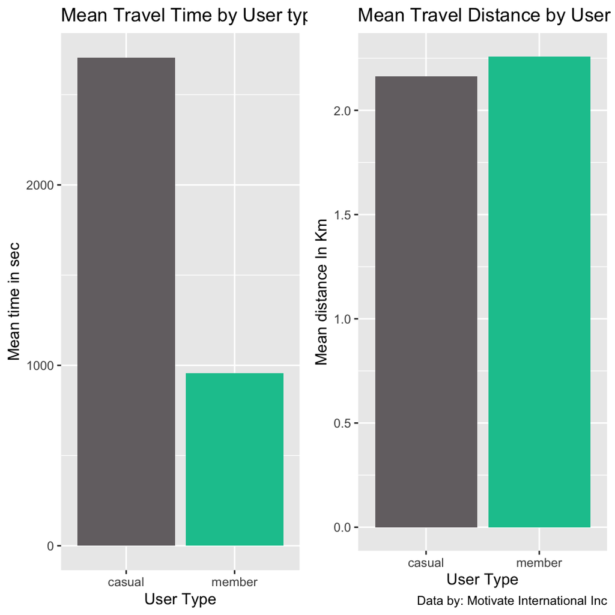

```r
userType_means <- all_tripdata_clean %>%
                  group_by(member_casual) %>%
                  summarise(mean_time = mean(ride_length),mean_distance = mean(ride_distance))

membervstime <- ggplot(userType_means) +
                geom_col(mapping=aes(x=member_casual,y=mean_time,fill=member_casual), show.legend = FALSE) +
                labs(title = "Mean Travel Time by User type",x="User Type",y="Mean time in sec") +
                scale_fill_manual(values = c("casual" = "#746F72","member" = "#0ec49d"))


membervsdistance <- ggplot(userType_means) +
                    geom_col(mapping=aes(x=member_casual,y=mean_distance,fill=member_casual), show.legend = FALSE) +
                    labs(title = "Mean Travel Distance by User type",x="User Type",y="Mean distance In Km",caption = "Data by: Motivate International Inc") +
                    scale_fill_manual(values = c("casual" = "#746F72","member" = "#0ec49d"))

grid.arrange(membervstime, membervsdistance, ncol = 2)
```

- Then, we check the number of rides differences by weekday:

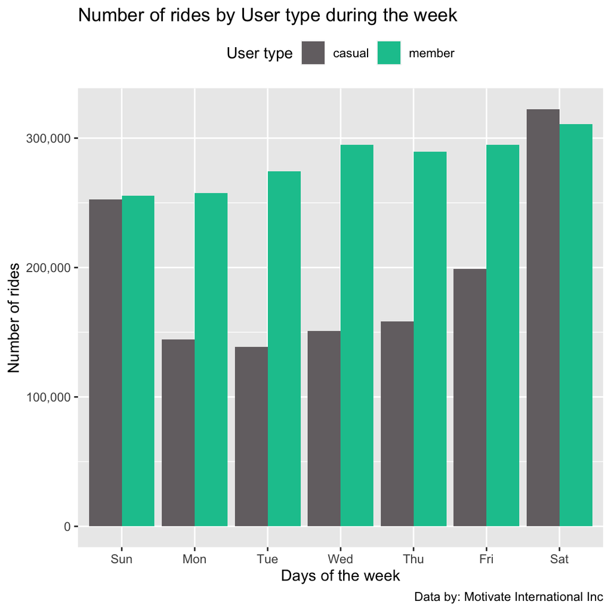

```r
all_tripdata_clean %>%
    mutate(weekday = wday(started_at, label = TRUE)) %>%
    group_by(member_casual, weekday) %>%
    summarise(number_of_rides = n()
        ,average_duration = mean(ride_length),.groups = 'drop') %>%
    arrange(member_casual, weekday)  %>%
    ggplot(aes(x = weekday, y = number_of_rides, fill = member_casual)) +
        geom_col(position = "dodge") +
        labs(title = "Number of rides by User type during the week",x="Days of the week",y="Number of rides",caption = "Data by: Motivate International Inc", fill="User type") +
        scale_fill_manual(values = c("casual" = "#746F72","member" = "#0ec49d")) +
        scale_y_continuous(labels = scales::comma) +
        theme(legend.position="top")
```

#### Analysis 1:

- It seems that the casual users travel the same average distance than the member users, but they have much longer rides, that would indicate a more leisure oriented usage vs a more “public transport” or pragmatic use of the bikes by the annual members.
- This idea is reinforced by the fact that annual users have a very stable use of the service during the week, but the casual users are more of a weekend user.

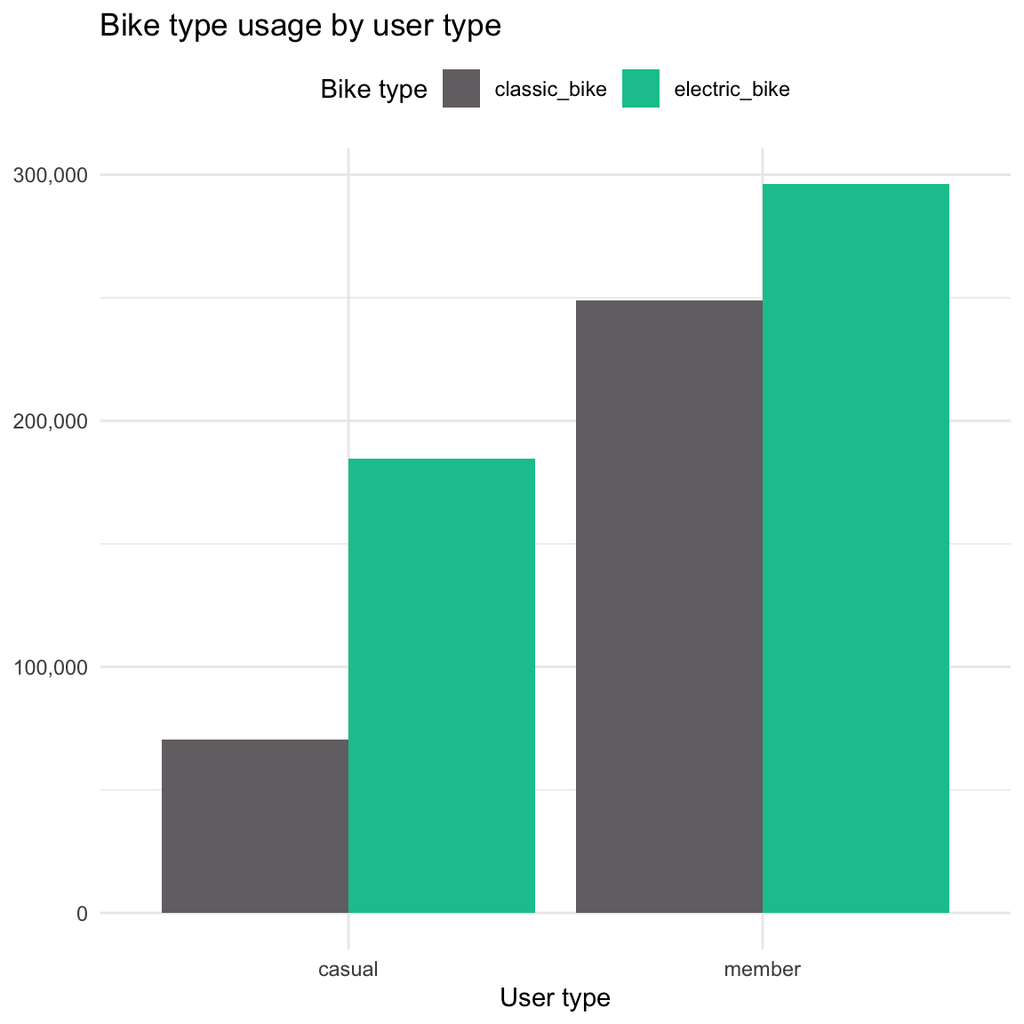

```r
# Create a new data frame with only the rows with info in the "bike type" column:
with_bike_type <- all_tripdata_clean %>%
                  filter(rideable_type=="classic_bike" | rideable_type=="electric_bike")

# Then, check the bike type usage by user type:
with_bike_type %>%
    group_by(member_casual,rideable_type) %>%
    summarise(totals=n(), .groups="drop")  %>%
    ggplot()+
        geom_col(aes(x=member_casual,y=totals,fill=rideable_type), position = "dodge") +
        labs(title = "Bike type usage by user type",x="User type",y=NULL, fill="Bike type") +
        scale_fill_manual(values = c("classic_bike" = "#746F72","electric_bike" = "#0ec49d")) +
        scale_y_continuous(labels = scales::comma) +
        theme_minimal() +
        theme(legend.position="top")
```

And their usage by both user types during a week:

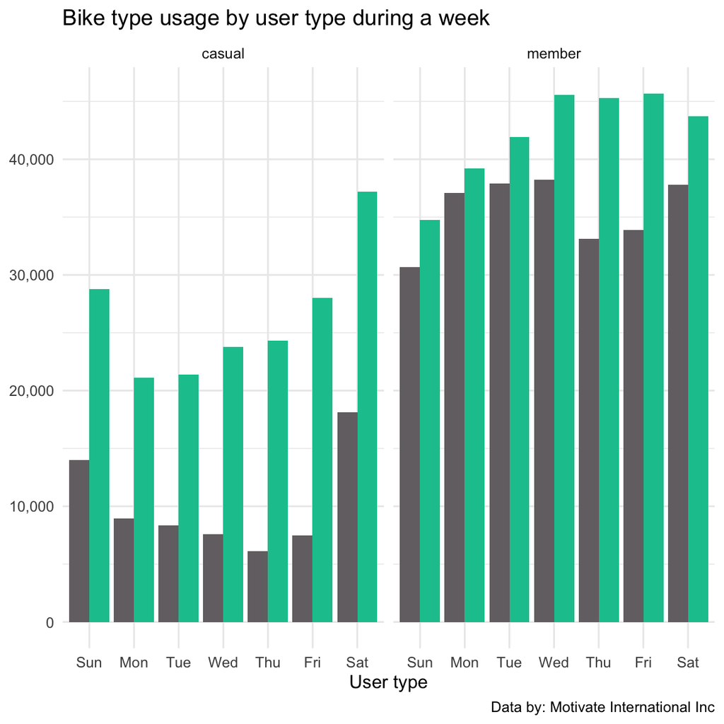

```r
with_bike_type %>%
    mutate(weekday = wday(started_at, label = TRUE)) %>%
    group_by(member_casual,rideable_type,weekday) %>%
    summarise(totals=n(), .groups="drop") %>%
    ggplot(aes(x=weekday,y=totals, fill=rideable_type)) +
        geom_col(, position = "dodge") +
        facet_wrap(~member_casual) +
        labs(title = "Bike type usage by user type during a week",x="User type",y=NULL,caption = "Data by: Motivate International Inc") +
        scale_fill_manual(values = c("classic_bike" = "#746F72","electric_bike" = "#0ec49d")) +
        scale_y_continuous(labels = scales::comma) +
        theme_minimal() +
        theme(legend.position="none")
```

Let’s check now the coordinates data of the rides, to see if is there any interesting pattern:

- First, we create a table only for the most popular routes (>250 times)

```r
coordinates_table <- all_tripdata_clean %>%
                     filter(start_lng != end_lng & start_lat != end_lat) %>%
                     group_by(start_lng, start_lat, end_lng, end_lat, member_casual, rideable_type) %>%
                     summarise(total = n(),.groups="drop") %>%
                     filter(total > 250)
```

- Then, we create two sub tables for each user type:

```r
casual <- coordinates_table %>% filter(member_casual == "casual")
member <- coordinates_table %>% filter(member_casual == "member")
```

- Let’s store bounding box coordinates for ggmap:

```r
chi_bb <- c(
  left = -87.700424,
  bottom = 41.790769,
  right = -87.554855,
  top = 41.990119
)

#Here we store the stamen map of Chicago
chicago_stamen <- get_stamenmap(
  bbox = chi_bb,
  zoom = 12,
  maptype = "toner"
)
```

- Then, we plot the data on the map:

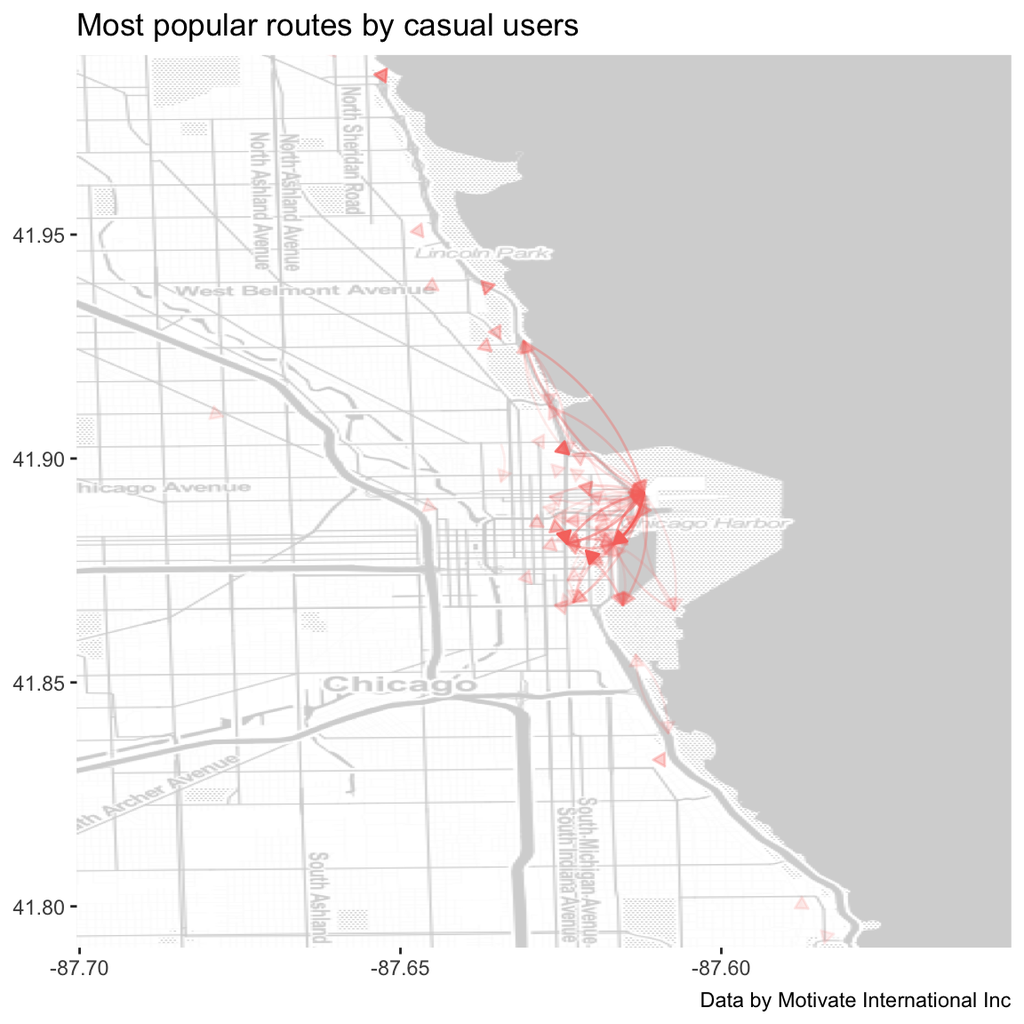

```r
ggmap(chicago_stamen,darken = c(0.8, "white")) +
   geom_curve(casual, mapping = aes(x = start_lng, y = start_lat, xend = end_lng, yend = end_lat, alpha= total, color=rideable_type), size = 0.5, curvature = .2,arrow = arrow(length=unit(0.2,"cm"), ends="first", type = "closed")) +
    coord_cartesian() +
    labs(title = "Most popular routes by casual users",x=NULL,y=NULL, color="User type", caption = "Data by Motivate International Inc") +
    theme(legend.position="none")
```

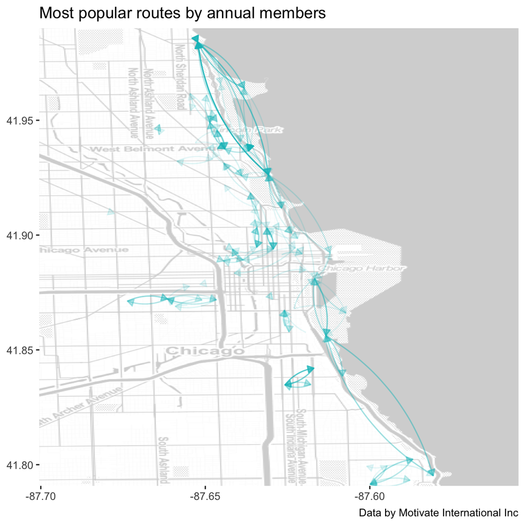

```r
ggmap(chicago_stamen,darken = c(0.8, "white")) +
    geom_curve(member, mapping = aes(x = start_lng, y = start_lat, xend = end_lng, yend = end_lat, alpha= total, color=rideable_type), size = 0.5, curvature = .2,arrow = arrow(length=unit(0.2,"cm"), ends="first", type = "closed")) +
    coord_cartesian() +
    labs(title = "Most popular routes by annual members",x=NULL,y=NULL, caption = "Data by Motivate International Inc") +
    theme(legend.position="none")
```

#### Analysis 3:

- The coordinates data resulted to be very interesting, as we can clearly see the casual is usually located around the center of the town, with all their trips located around that area which makes sense given that they have a more relaxed leisure rides, on weekends probably also tourist or sightseeing related rides, that naturally focus more on the downtown area where most of the interest points are.
- This contrasts heavily with the longer range of the annual users that connect the downtown with the outskirts of the city, that would suggest they are mostly people that live outside the downtown and use the service to commute everyday to their works in the city.

# V. Act

- Taking in consideration both the business task: What could motivate the “casual” users to change to an annual subscription based on their behavior? and the insights we’ve learned from the available data we can make some conclusions.
  - The Casual users have leisure, and tourism rides mostly on weekends and using electric bikes.
  - The Annual users have commute or pragmatic rides, during all week using both electric & classic bikes
- I would share this info, the data and my analysis to the marketing team, and I would suggest that in order to convert the casual to the annual users it would be interesting to focus the messages on the leisure aspect of the service, and maybe offer some kind of promotion related to weekends and/or electric bikes.

## Other Considerations for Further Exploration

- Collect data on full route of a bike during rental, not just start and end locations, to analyze if certain areas/geospatial factors constitute certain bike types.
- Include data on whether a casual rider uses a single-ride pass or full-day pass, to analyze how pricing may impact usage.